# Exploration

Panther

Jan 28,2018

## Load Data

```r
library(quanteda); library(tidyverse); library(TTR);library(ggplot2);library(scales); library(fOptions); library(pastecs); library(psych);library(crayon);library(PerformanceAnalytics);library(stats);

# here data read is being processed
t <- read_csv("../data/data.csv")
```

# Process Data

```r
GSPC <- read_csv("../data/^GSPC.csv")
LIBOR <- read_csv("../data/USD3MTD156N.csv")
Treasury <- read_csv("../data/DTB3.csv")
VIX <- read_csv("../data/^VIX.csv")
t<-cbind(GSPC,Treasury$DTB3[match(GSPC$Date,Treasury$DATE)])
t<-cbind(t,VIX$Close[match(t$Date,VIX$Date)])
t<-t[,c(1,5,8,9)]
t<- t[-1:(-10054+120),]  # extra 120 for training signal, will remove later
colnames(t)[3] <- "Free_rate"
colnames(t)[4] <- "VIX"
t$Free_rate = as.numeric(as.character(t$Free_rate))
```

# Missing Data

```r
sum(is.na(t))
```

```
## [1] 182
```

```r
sum(is.na(t$Close))
```

```
## [1] 0
```

```r
sum(is.na(t$Free_rate))
```

```
## [1] 62
```

```r
sum(is.na(t$VIX))
```

```
## [1] 120
```

```r
which(is.na(t$Free_rate))
```

```
##  [1]   63  130  315  340  387  572  592  639  824  846  891 1076 1099 1144
## [15] 1328 1352 1395 1580 1647 1837 1857 1904 2089 2110 2340 2362 2591 2614
## [29] 2843 3090 3115 3346 3366 3597 3618 3847 3870 4099 4123 4350 4600 4625
## [43] 4856 4877 5107 5129 5358 5381 5610 5634 5861 5884 6115 6135 6366 6387
## [57] 6617 6639 6868 6892 7119 7189
```

```r
#count(which(is.na(t$Free_rate)))

temp <- which(is.na(t$Free_rate))
for (i in temp)
  t$Free_rate[i] <- mean(t$Free_rate[(i-5):(i+5)], na.rm=TRUE)

sum(is.na(t$Free_rate))
```

```
## [1] 0
```

# Moving Average and momentum signal

```r
t$SMA60 <- SMA(t$Close,60)
t$SMA120 <- SMA(t$Close,120)
t<- t[-1:-120,]     # here remove training 120
for (i in seq_along(t$SMA120)){
  if (t$SMA60[i]>t$SMA120[i])
     t$signal[i] = 1            # signal = 1 is buy singal
  else if (t$SMA60[i]<t$SMA120[i])
     t$signal[i] = 0
  else
     t$signal[i] = t$singal[i-1]
}
```

# Plot SPC and moving average

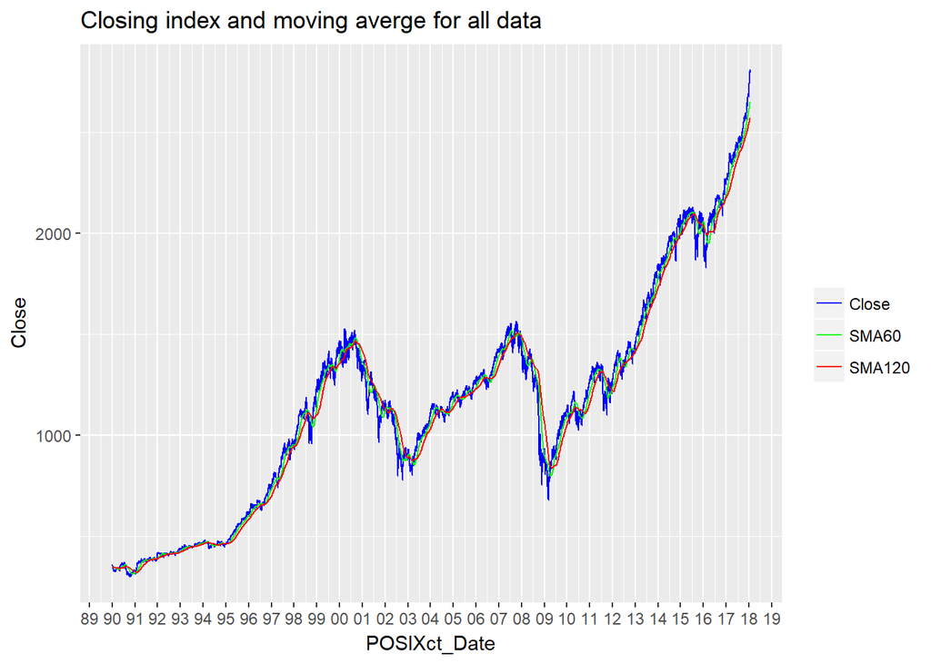

```r
t$POSIXct_Date <- as.POSIXct(t$Date)

ggplot(t,aes(x=POSIXct_Date)) +
  geom_line(aes(y=Close,color="Close")) +
  geom_line(aes(y=SMA60,color="SMA60")) +
  geom_line(aes(y=SMA120,color="SMA120"))+
  scale_x_datetime(breaks=date_breaks("1 year"),labels = date_format("%y")) +
  labs(color="Legend")+
  scale_colour_manual("", breaks = c("Close", "SMA60","SMA120"),
                          values = c("blue", "red","green")) +
  ggtitle("Closing index and moving averge for all data")
```

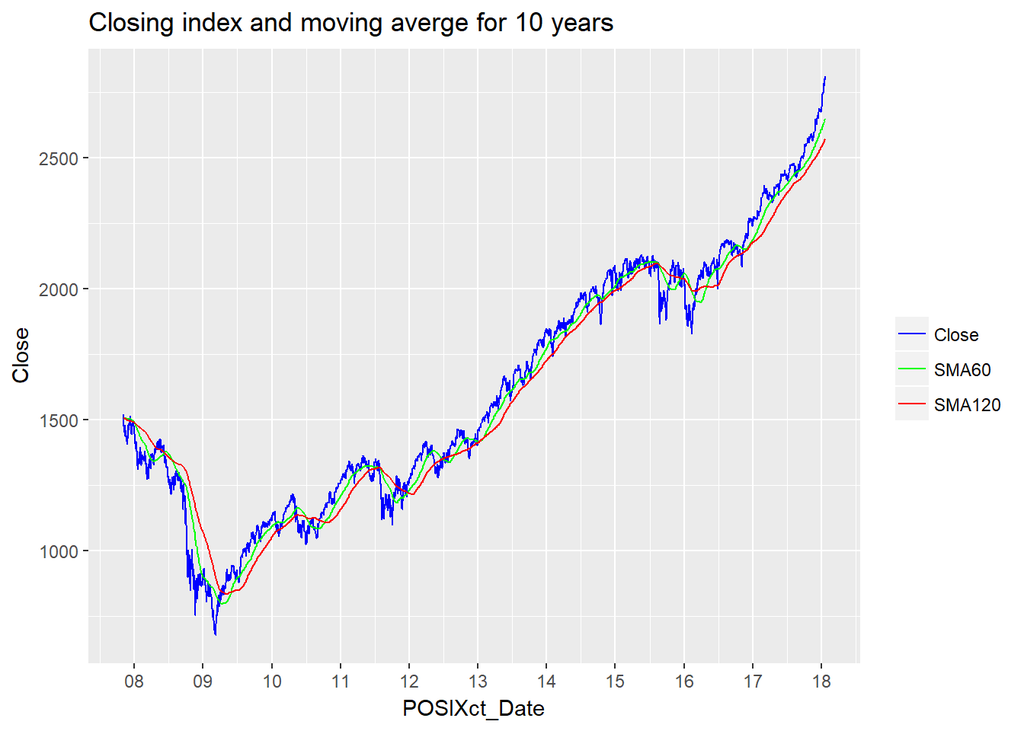

```r
a = 4500
c = 7069

ggplot(t[a:c,],aes(x=POSIXct_Date)) +
  geom_line(aes(y=Close,color="Close")) +
  geom_line(aes(y=SMA60,color="SMA60")) +
  geom_line(aes(y=SMA120,color="SMA120"))+
  scale_x_datetime(breaks=date_breaks("1 year"),labels = date_format("%y")) +
  labs(color="Legend")+
  scale_colour_manual("", breaks = c("Close", "SMA60","SMA120"),
                          values = c("blue", "red","green")) +
  ggtitle("Closing index and moving averge for 10 years")
```

Momentum effect Strong autocorrelation

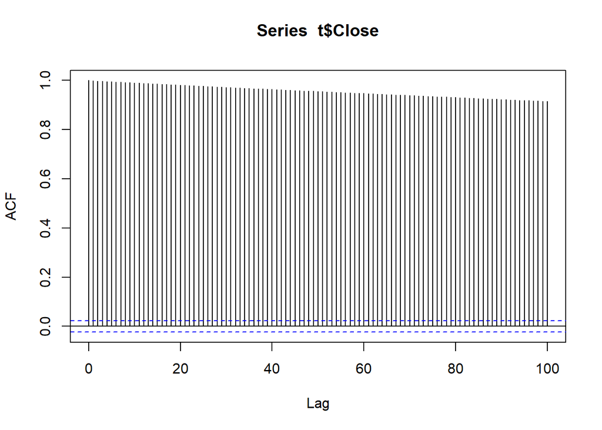

```r
acf(t$Close,lag.max = 100,type='correlation')
```

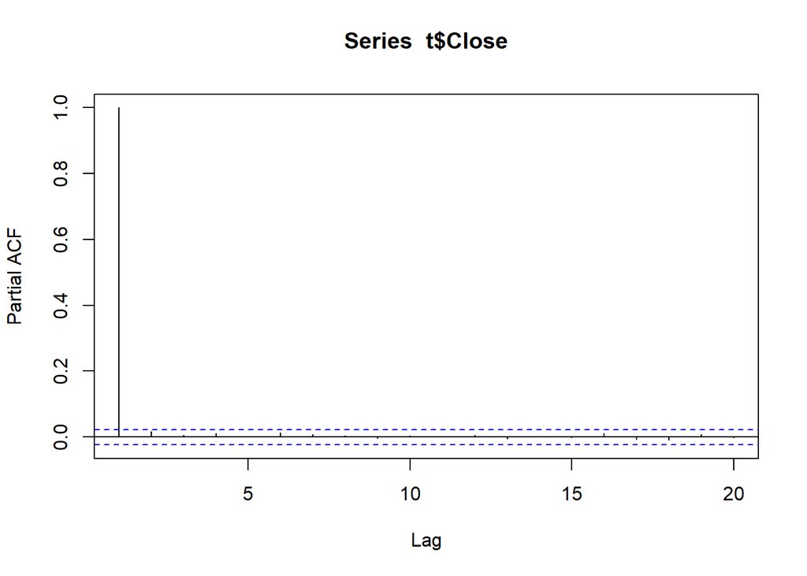

```r
pacf(t$Close,lag.max = 20)
```

## Create portfolios

Absolute Return = shift between one lag of close prices Percentage Return = Absolute Return / last day close price ??Relative Return = Percentage return * anchor price(first day price of index) ??Better not use due to different products and performences

# portfolio 1

Buy/sell 1 index on today’s closing and close position next day

```r
t$port1_absreturn[1] = NA
t$port1_Perreturn[1] = NA
#t$port1_Relreturn[1] = NA


for (i in seq_along(t$Close[1:(length(t$Close)-1)])){
  if (t$signal[i]== 1){
     t$port1_absreturn[i+1] = t$Close[i+1]-t$Close[i]
     t$port1_Perreturn[i+1] = (t$Close[i+1]-t$Close[i]) / t$Close[i]
#     t$port1_Relreturn[i+1] = t$port1_Perreturn[i+1] * t$Close[1]
     }
  else{
     t$port1_absreturn[i+1] = t$Close[i]-t$Close[i+1]
     t$port1_Perreturn[i+1] = (t$Close[i]-t$Close[i+1]) / t$Close[i]
#     t$port1_Relreturn[i+1] = t$port1_Perreturn[i+1] * t$Close[1]
     }
}
```

# portfolio 2

Buy/sell at the money option(90 days maturity) on today’s closing and close position next day Volatility is VIX Risk free rate is 90 days T-bill rate 1/100 option means underline asset is 1 index

```r
t$port2_absreturn[1] = NA
t$port2_Perreturn[1] = NA
#t$port2_Relreturn[1] = NA

#if (t$signal[1] == 1) {
#  cc <- GBSOption("c",t$Close[1],t$Close[1],0.246575342,(t$Free_rate[1]/100),0,(t$VIX[1]/100))
#  } else {
#  cc <- GBSOption("p",t$Close[1],t$Close[1],0.246575342,(t$Free_rate[1]/100),0,(t$VIX[1]/100))}

for (i in seq_along(t$Close[1:(length(t$Close)-1)])){

  if (t$signal[i]== 1){
     aa <- GBSOption("c",t$Close[i+1],t$Close[i],(90-as.numeric(difftime(t$Date[i+1],t$Date[i])))/365,(t$Free_rate[i+1]/100),0,(t$VIX[i+1]/100))
     bb <- GBSOption("c",t$Close[i],t$Close[i],0.246575342,(t$Free_rate[i]/100),0,(t$VIX[i]/100))
    } else{
     aa <- GBSOption("p",t$Close[i+1],t$Close[i],(90-as.numeric(difftime(t$Date[i+1],t$Date[i])))/365,(t$Free_rate[i+1]/100),0,(t$VIX[i+1]/100))
     bb <- GBSOption("p",t$Close[i],t$Close[i],0.246575342,(t$Free_rate[i]/100),0,(t$VIX[i]/100))
    }
     t$port2_absreturn[i+1] = aa@price-bb@price
     t$port2_Perreturn[i+1] = (aa@price-bb@price) / bb@price
#     t$port2_Relreturn[i+1] = t$port2_Perreturn[i+1] * t$Close[1]
}
```

# portfolio 3

Buy at the money straddle(90 days maturity) on today’s closing and close position next day Volatility is VIX Risk free rate is 90 days T-bill rate 1/100 option means underline asset is 1 index

```r
t$port3_absreturn[1] = NA
t$port3_Perreturn[1] = NA
#t$port3_Relreturn[1] = NA

#ca <- GBSOption("c",t$Close[1],t$Close[1],0.246575342,(t$Free_rate[1]/100),0,(t$VIX[1]/100))
#cb <- GBSOption("p",t$Close[1],t$Close[1],0.246575342,(t$Free_rate[1]/100),0,(t$VIX[1]/100))
#cc = ca@price + cb@price

for (i in seq_along(t$Close[1:(length(t$Close)-1)])){
     aa1 <- GBSOption("c",t$Close[i+1],t$Close[i],(90-as.numeric(difftime(t$Date[i+1],t$Date[i])))/365,(t$Free_rate[i+1]/100),0,(t$VIX[i+1]/100))
          aa2 <- GBSOption("p",t$Close[i+1],t$Close[i],(90-as.numeric(difftime(t$Date[i+1],t$Date[i])))/365,(t$Free_rate[i+1]/100),0,(t$VIX[i+1]/100))
     bb1 <- GBSOption("c",t$Close[i],t$Close[i],0.246575342,(t$Free_rate[i]/100),0,(t$VIX[i]/100))
     bb2 <- GBSOption("p",t$Close[i],t$Close[i],0.246575342,(t$Free_rate[i]/100),0,(t$VIX[i]/100))

     t$port3_absreturn[i+1] = (aa1@price+aa2@price-bb1@price-bb2@price)
     t$port3_Perreturn[i+1] = (aa1@price+aa2@price-bb1@price-bb2@price) / (bb1@price+bb2@price)
#     t$port3_Relreturn[i+1] = t$port3_Perreturn[i+1] * t$Close[1]
}
```

# portfolio 4

Buy at the money straddle(90 days maturity but remain life decrease until rebalance at maturity) - on today’s closing and close position next day Volatility is VIX Risk free rate is 90 days T-bill rate 1/100 option means underline asset is 1 index

```r
t$port4_absreturn[1] = NA
t$port4_Perreturn[1] = NA
#t$port4_Relreturn[1] = NA

#ca <- GBSOption("c",t$Close[1],t$Close[1],0.246575342,(t$Free_rate[1]/100),0,(t$VIX[1]/100))
#cb <- GBSOption("p",t$Close[1],t$Close[1],0.246575342,(t$Free_rate[1]/100),0,(t$VIX[1]/100))
#cc = ca@price + cb@price

#date.lookup <- format(seq(as.Date("2000-01-02"), as.Date("2018-1-19"), by = "1 day"))
#date.except <- subset(b, !(y %in% a$x))
#match("2024-01-19", date.lookup)

count=0   #count days passed

for (i in seq_along(t$Close[1:(length(t$Close)-1)])){

  if (as.numeric(difftime(t$Date[i+1],t$Date[i])) == 1){   #workday
    count = count+1}
  else {                                            # not workday
    count = count+as.numeric(difftime(t$Date[i+1],t$Date[i])) }

  if (count <= 89){
    Remaina = 90 - count         # today's remain
    Remainb = Remaina + 1}        # previous day's remain
  else if (count >= 90) {       # expired already, adjuste to 90 days passed
    Remaina = 0                 # today's remain
    Remainb = 1                 # previous day's remain
    count = 0 }                 # after expired, rebalance

  aa1 <- GBSOption("c",t$Close[i+1],t$Close[i],0.246575342*Remaina/90,(t$Free_rate[i+1]/100),0,(t$VIX[i+1]/100))
  aa2 <- GBSOption("p",t$Close[i+1],t$Close[i],0.246575342*Remaina/90,(t$Free_rate[i+1]/100),0,(t$VIX[i+1]/100))
  bb1 <- GBSOption("c",t$Close[i],t$Close[i],0.246575342*Remainb/90,(t$Free_rate[i]/100),0,(t$VIX[i]/100))
  bb2 <- GBSOption("p",t$Close[i],t$Close[i],0.246575342*Remainb/90,(t$Free_rate[i]/100),0,(t$VIX[i]/100))

  t$port4_absreturn[i+1] = (aa1@price+aa2@price-bb1@price-bb2@price)
  t$port4_Perreturn[i+1] = (aa1@price+aa2@price-bb1@price-bb2@price) / (bb1@price+bb2@price)
#  t$port4_Relreturn[i+1] = t$port4_Perreturn[i+1] * t$Close[1]
}
```

# Dump first day NA return

```r
t <- t[-1,]
```

# Line Plot Absolute Return

```r
#ggplot(t,aes(x=Date)) +
#  geom_line(aes(y=port1_absreturn))

#ggplot(t,aes(x=Date)) +
#  geom_line(aes(y=port2_absreturn))

#ggplot(t,aes(x=Date)) +
#  geom_line(aes(y=port3_absreturn))

#ggplot(t,aes(x=Date)) +
#  geom_line(aes(y=port4_absreturn))
```

# Line Plot Percentage Return

```r
#ggplot(t,aes(x=Date)) +
#  geom_line(aes(y=port1_Perreturn))

#ggplot(t,aes(x=Date)) +
#  geom_line(aes(y=port2_Perreturn))

#ggplot(t,aes(x=Date)) +
#  geom_line(aes(y=port3_Perreturn))

#ggplot(t,aes(x=Date)) +
#  geom_line(aes(y=port4_Perreturn))
```

# Scatter of Absolute Return

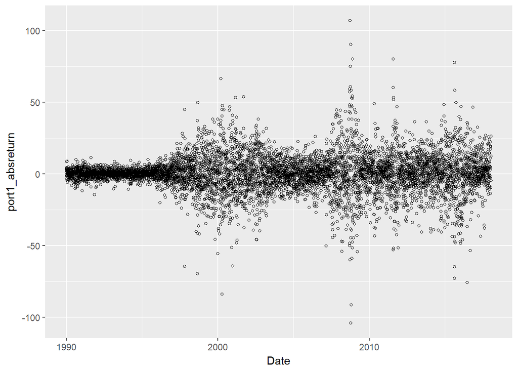

```r
ggplot(t,aes(x=Date)) +
  geom_point(aes(y=port1_absreturn),size =1, shape= 1)
```

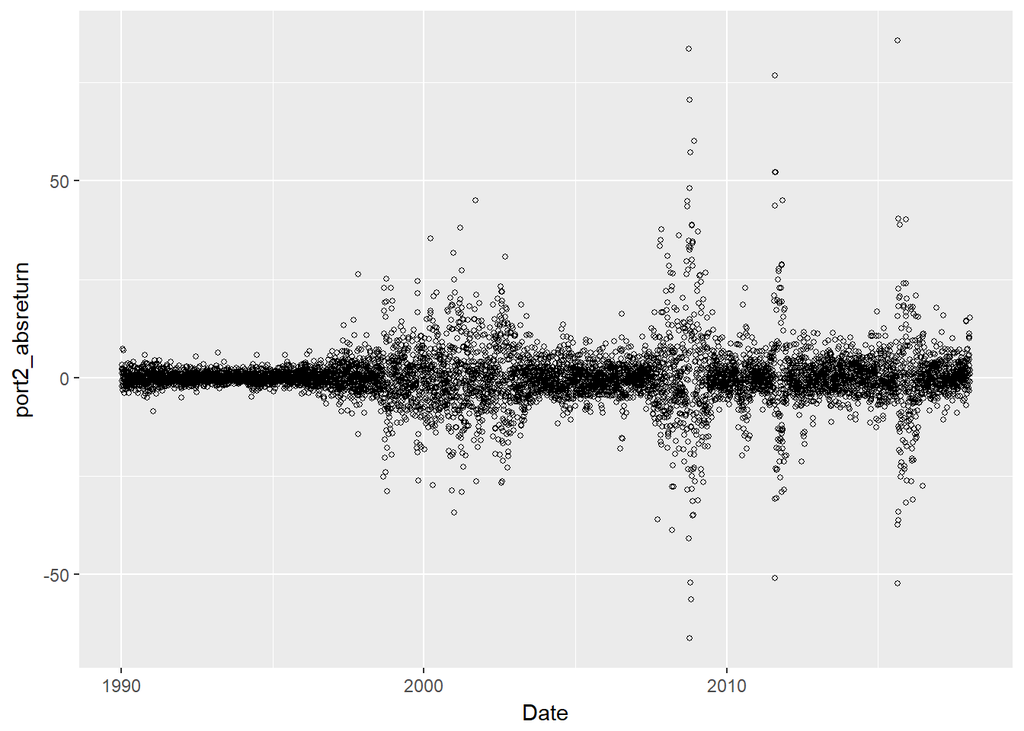

```r
ggplot(t,aes(x=Date)) +
  geom_point(aes(y=port2_absreturn),size =1, shape= 1)
```

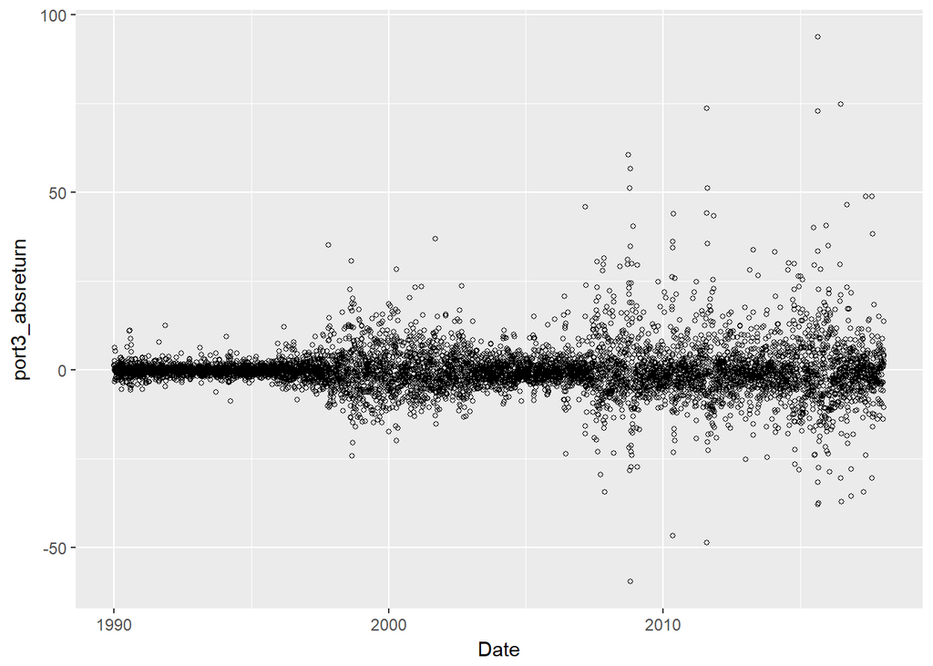

```r
ggplot(t,aes(x=Date)) +
  geom_point(aes(y=port3_absreturn),size =1, shape= 1)
```

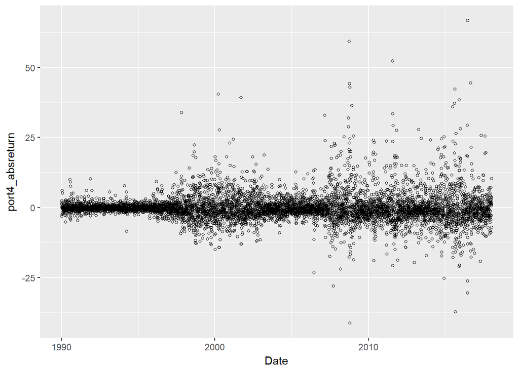

```r
ggplot(t,aes(x=Date)) +
  geom_point(aes(y=port4_absreturn),size =1, shape= 1)
```

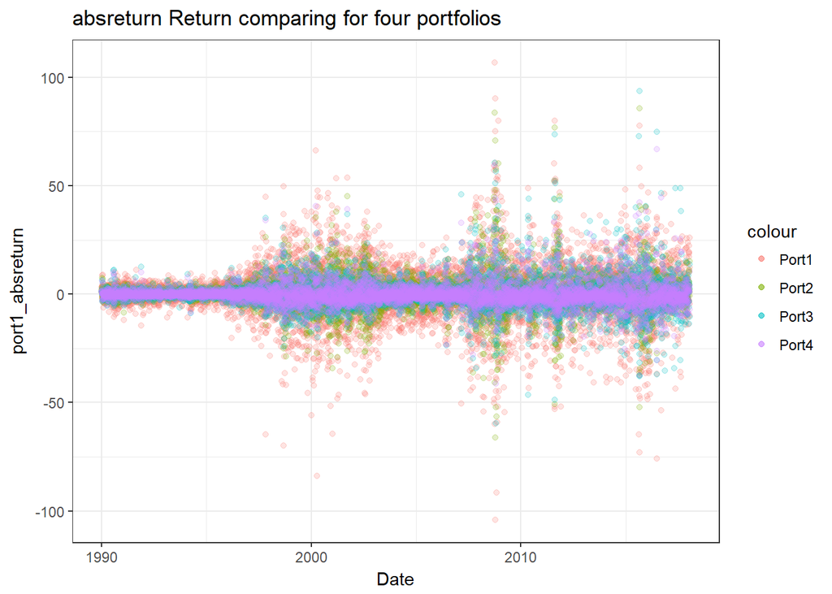

```r
ggplot(t,aes(x=Date)) +
  geom_point(aes(y=port1_absreturn,color="Port1"),alpha=0.2) +
  geom_point(aes(y=port2_absreturn,color="Port2"),alpha=0.2) +
  geom_point(aes(y=port3_absreturn,color="Port3"),alpha=0.2) +
  geom_point(aes(y=port4_absreturn,color="Port4"),alpha=0.2) +
  theme_bw() +
  ggtitle("absreturn Return comparing for four portfolios")
```

```r
#a = 4500
#c = 7068

#ggplot(t[a:c,],aes(x=Date)) +
#  geom_point(aes(y=port1_absreturn,color="Port1"),alpha=0.5,shape= 1) +
#  geom_point(aes(y=port2_absreturn,color="Port2"),alpha=0.5,shape= 0) +
#  geom_point(aes(y=port3_absreturn,color="Port3"),alpha=0.5,shape= 2) +
#  geom_point(aes(y=port4_absreturn,color="Port4"),alpha=0.5,shape= 5) +
#  theme_bw() +
#  ggtitle("absreturn Return comparing for four portfolios in 10 years")
```

# Scatter of Percentage Return

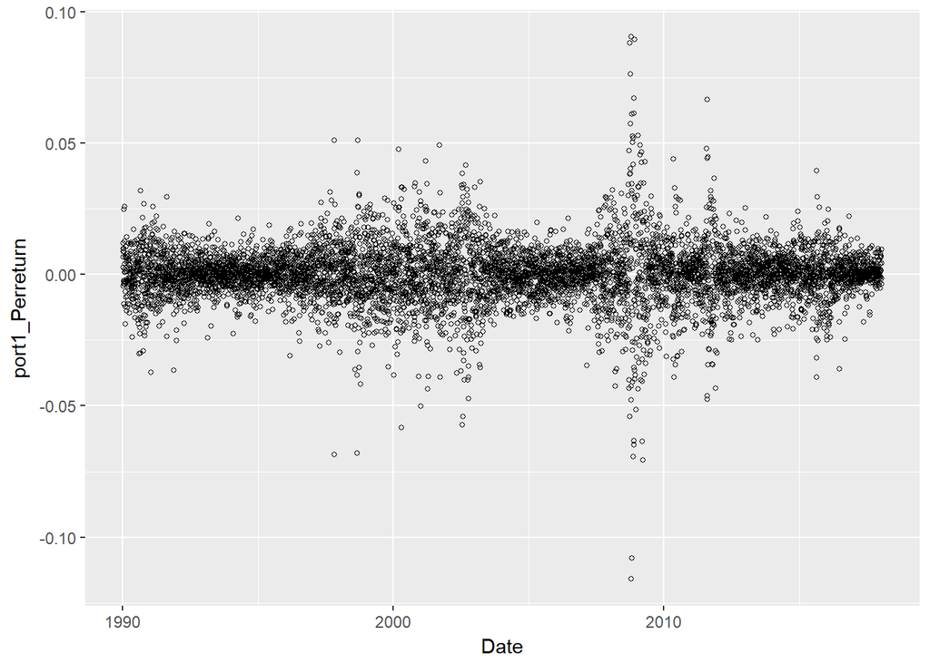

```r
ggplot(t,aes(x=Date)) +
  geom_point(aes(y=port1_Perreturn),size =1, shape= 1)
```

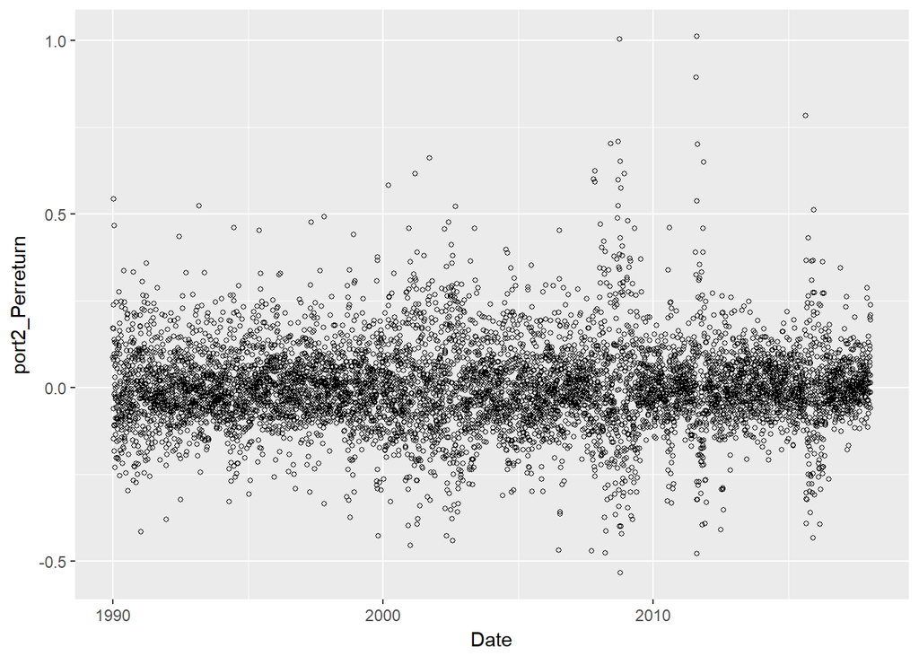

```r
ggplot(t,aes(x=Date)) +
  geom_point(aes(y=port2_Perreturn),size =1, shape= 1)
```

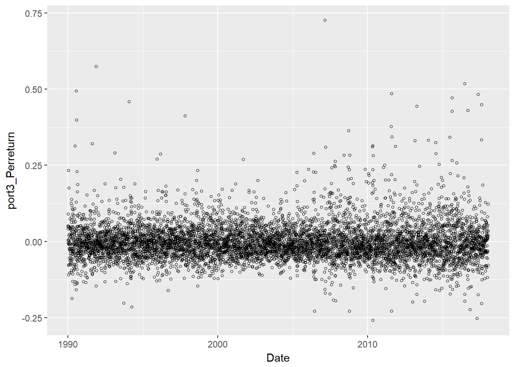

```r
ggplot(t,aes(x=Date)) +
  geom_point(aes(y=port3_Perreturn),size =1, shape= 1)
```

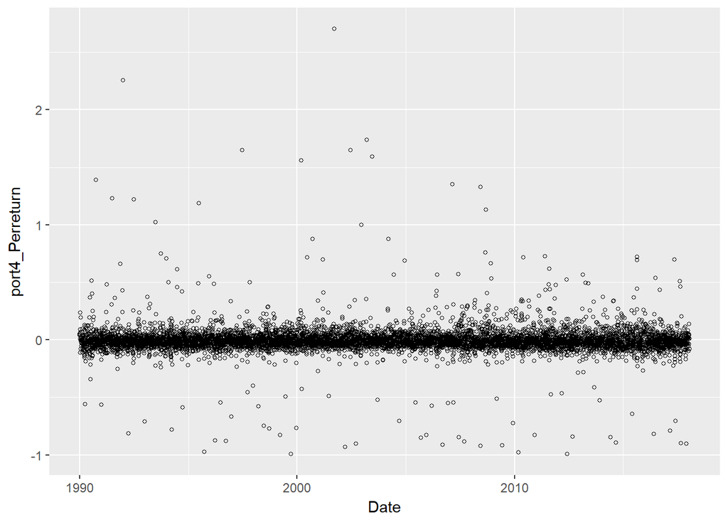

```r
ggplot(t,aes(x=Date)) +
  geom_point(aes(y=port4_Perreturn),size =1, shape= 1)
```

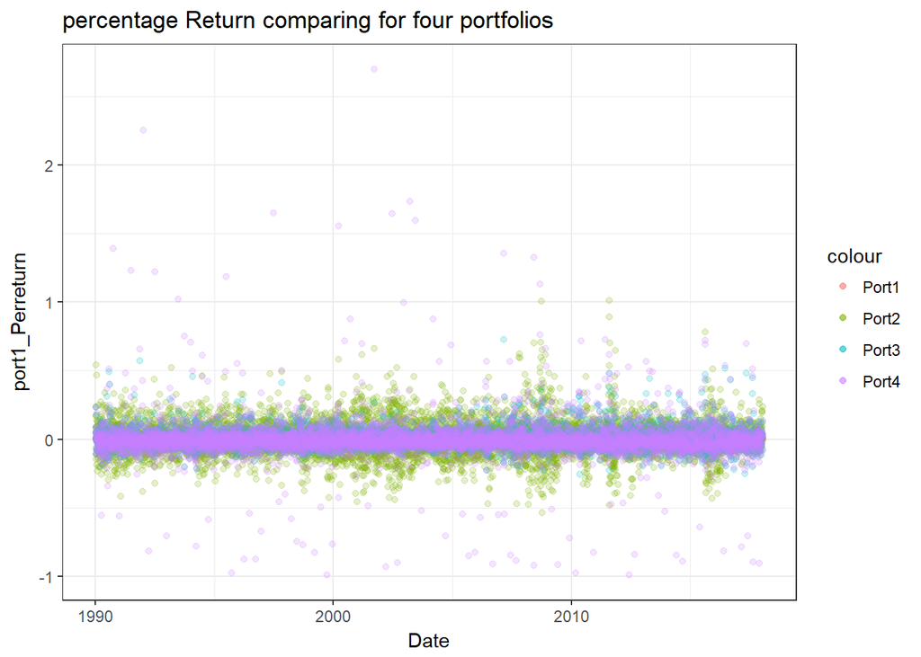

```r
ggplot(t,aes(x=Date)) +
  geom_point(aes(y=port1_Perreturn,color="Port1"),alpha=0.2) +
  geom_point(aes(y=port2_Perreturn,color="Port2"),alpha=0.2) +
  geom_point(aes(y=port3_Perreturn,color="Port3"),alpha=0.2) +
  geom_point(aes(y=port4_Perreturn,color="Port4"),alpha=0.2) +
  theme_bw() +
  ggtitle("percentage Return comparing for four portfolios")
```

```r
#a = 4500
#c = 7068

#ggplot(t[a:c,],aes(x=Date)) +
#  geom_point(aes(y=port1_Perreturn,color="Port1"),alpha=0.5,shape= 1) +
#  geom_point(aes(y=port2_Perreturn,color="Port2"),alpha=0.5,shape= 0) +
#  geom_point(aes(y=port3_Perreturn,color="Port3"),alpha=0.5,shape= 2) +
#  geom_point(aes(y=port4_Perreturn,color="Port4"),alpha=0.5,shape= 5) +
#  theme_bw() +
#  ggtitle("percentage Return comparing for four portfolios in 10 years")
```

# Histogram of Absolute Return

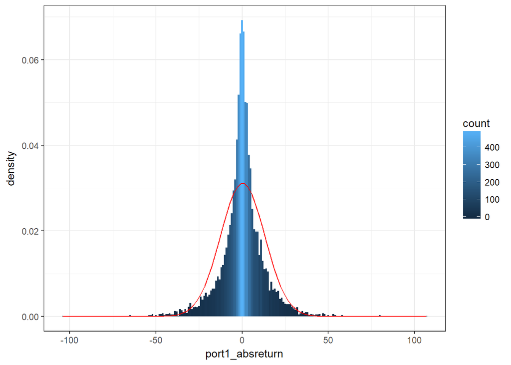

```r
ggplot(t,aes(x = port1_absreturn)) +
  geom_histogram(binwidth = 1,aes(y=..density..,fill=..count..)) +
  stat_function(fun = dnorm, color="red", args = list(mean = mean(t$port1_absreturn),sd = sd(t$port1_absreturn))) +
  theme_bw()
```

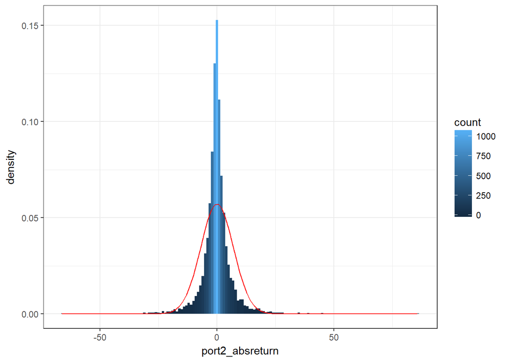

```r
ggplot(t,aes(x = port2_absreturn)) +
  geom_histogram(binwidth = 1,aes(y=..density..,fill=..count..)) +
  stat_function(fun = dnorm, color="red", args = list(mean = mean(t$port2_absreturn),sd = sd(t$port2_absreturn))) +
  theme_bw()
```

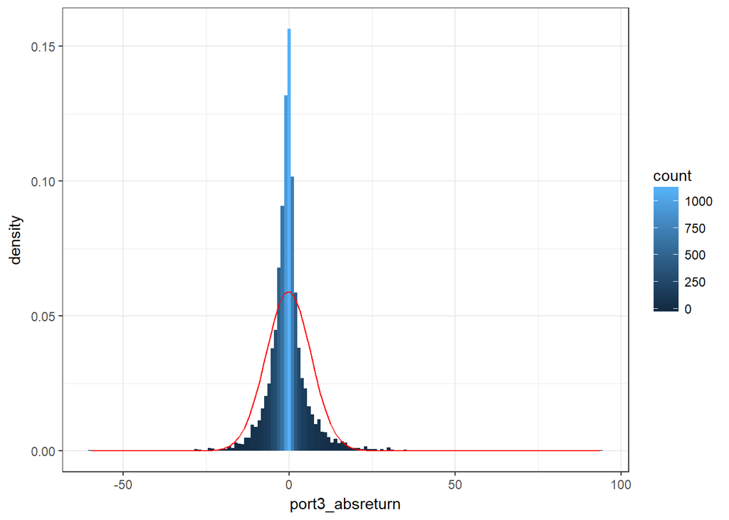

```r
ggplot(t,aes(x = port3_absreturn)) +
  geom_histogram(binwidth = 1,aes(y=..density..,fill=..count..)) +
  stat_function(fun = dnorm, color="red", args = list(mean = mean(t$port3_absreturn),sd = sd(t$port3_absreturn))) +
  theme_bw()
```

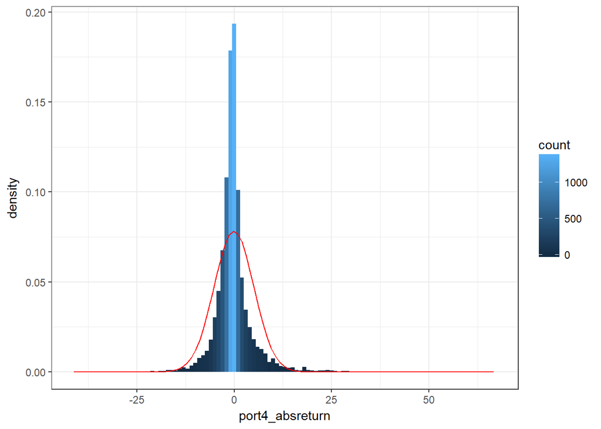

```r
ggplot(t,aes(x = port4_absreturn)) +
  geom_histogram(binwidth = 1,aes(y=..density..,fill=..count..)) +
  stat_function(fun = dnorm, color="red", args = list(mean = mean(t$port4_absreturn),sd = sd(t$port4_absreturn))) +
  theme_bw()
```

```r
#a = 4500
#c = 7068

#print("Absolute Return in 10 years")

#ggplot(t[a:c,],aes(x = port1_absreturn)) +
#  geom_histogram(binwidth = 1,aes(y=..density..,fill=..count..)) +
#  stat_function(fun = dnorm, color="red", args = list(mean = mean(t$port1_absreturn),sd = sd(t$port1_absreturn))) +
#  theme_bw()

#ggplot(t[a:c,],aes(x = port2_absreturn)) +
#  geom_histogram(binwidth = 1,aes(y=..density..,fill=..count..)) +
#  stat_function(fun = dnorm, color="red", args = list(mean = mean(t$port2_absreturn),sd = sd(t$port2_absreturn))) +
#  theme_bw()

#ggplot(t[a:c,],aes(x = port3_absreturn)) +
#  geom_histogram(binwidth = 1,aes(y=..density..,fill=..count..)) +
#  stat_function(fun = dnorm, color="red", args = list(mean = mean(t$port3_absreturn),sd = sd(t$port3_absreturn))) +
#  theme_bw()

#ggplot(t[a:c,],aes(x = port4_absreturn)) +
#  geom_histogram(binwidth = 1,aes(y=..density..,fill=..count..)) +
#  stat_function(fun = dnorm, color="red", args = list(mean = mean(t$port4_absreturn),sd = sd(t$port4_absreturn))) +
#  theme_bw()
```

# Histogram of Percentage Return

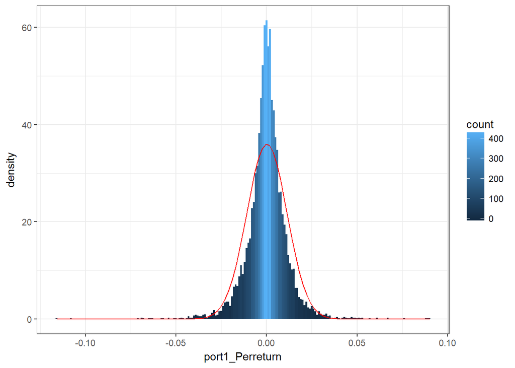

```r
ggplot(t,aes(x = port1_Perreturn)) +
  geom_histogram(binwidth = 0.001,aes(y=..density..,fill=..count..)) +
  stat_function(fun = dnorm, color="red", args = list(mean = mean(t$port1_Perreturn),sd = sd(t$port1_Perreturn))) +
  theme_bw()
```

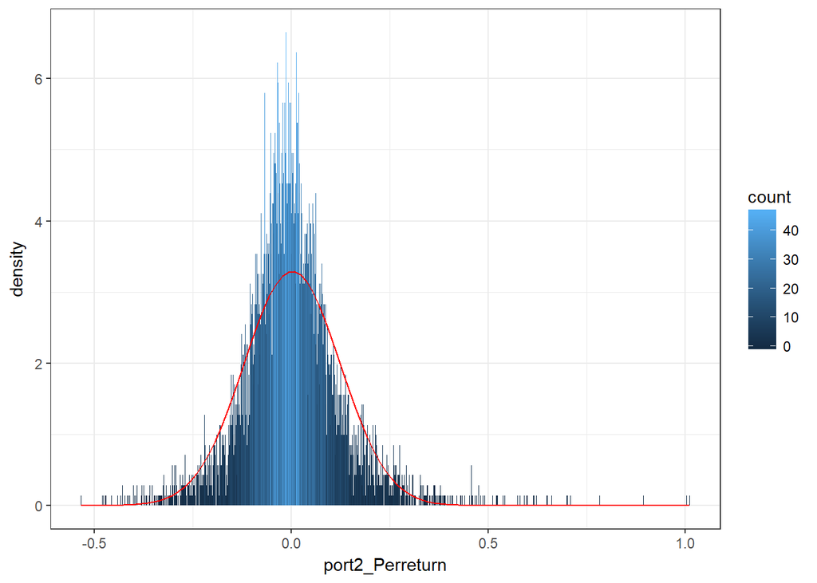

```r
ggplot(t,aes(x = port2_Perreturn)) +
  geom_histogram(binwidth = 0.001,aes(y=..density..,fill=..count..)) +
  stat_function(fun = dnorm, color="red", args = list(mean = mean(t$port2_Perreturn),sd = sd(t$port2_Perreturn))) +
  theme_bw()
```

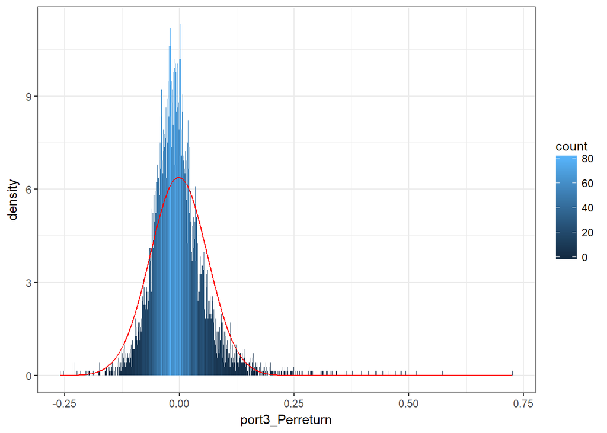

```r
ggplot(t,aes(x = port3_Perreturn)) +
  geom_histogram(binwidth = 0.001,aes(y=..density..,fill=..count..)) +
  stat_function(fun = dnorm, color="red", args = list(mean = mean(t$port3_Perreturn),sd = sd(t$port3_Perreturn))) +
  theme_bw()
```

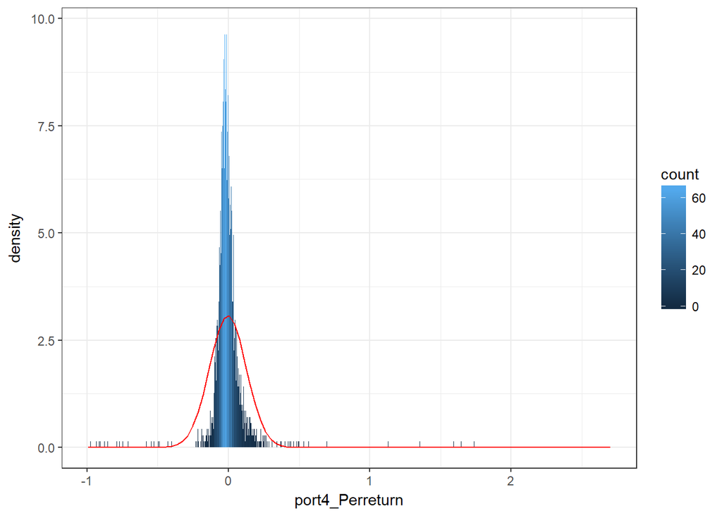

```r
ggplot(t,aes(x = port4_Perreturn)) +
  geom_histogram(binwidth = 0.001,aes(y=..density..,fill=..count..)) +
  stat_function(fun = dnorm, color="red", args = list(mean = mean(t$port4_Perreturn),sd = sd(t$port4_Perreturn))) +
  theme_bw()
```

```r
#a = 4500
#c = 7068

#print("Percentage Return in 10 years")

#ggplot(t[a:c,],aes(x = port1_Perreturn)) +
#  geom_histogram(binwidth = 0.001,aes(y=..density..,fill=..count..)) +
#  stat_function(fun = dnorm, color="red", args = list(mean = mean(t$port1_Perreturn),sd = sd(t$port1_Perreturn))) +
#  theme_bw()

#ggplot(t[a:c,],aes(x = port2_Perreturn)) +
#  geom_histogram(binwidth = 0.001,aes(y=..density..,fill=..count..)) +
#  stat_function(fun = dnorm, color="red", args = list(mean = mean(t$port2_Perreturn),sd = sd(t$port2_Perreturn))) +
#  theme_bw()

#ggplot(t[a:c,],aes(x = port3_Perreturn)) +
#  geom_histogram(binwidth = 0.001,aes(y=..density..,fill=..count..)) +
#  stat_function(fun = dnorm, color="red", args = list(mean = mean(t$port3_Perreturn),sd = sd(t$port3_Perreturn))) +
#  theme_bw()

#ggplot(t[a:c,],aes(x = port4_Perreturn)) +
#  geom_histogram(binwidth = 0.001,aes(y=..density..,fill=..count..)) +
#  stat_function(fun = dnorm, color="red", args = list(mean = mean(t$port4_Perreturn),sd = sd(t$port4_Perreturn))) +
#  theme_bw()
```

# QQ plot of Absolute Return

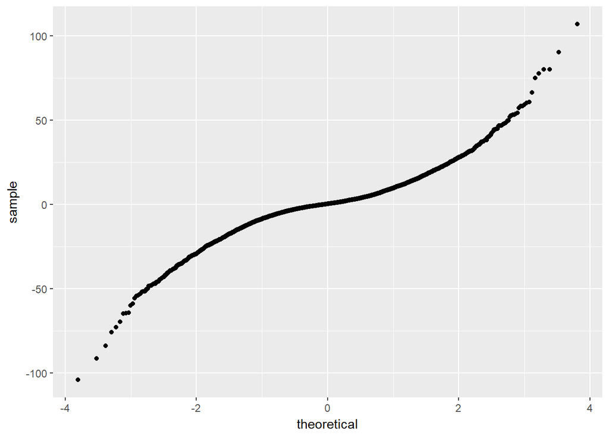

```r
ggplot(t, aes(sample=port1_absreturn)) +  stat_qq()
```

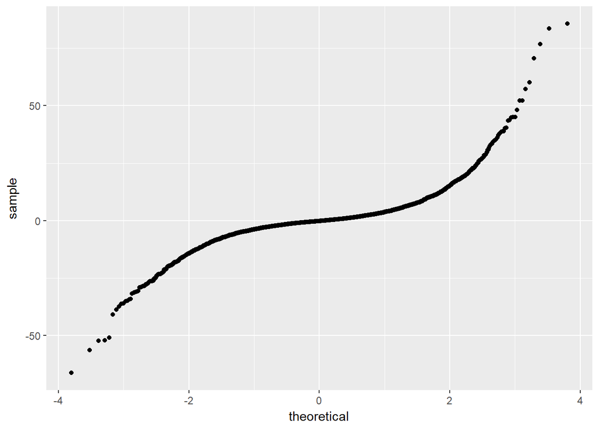

```r
ggplot(t, aes(sample=port2_absreturn)) +  stat_qq()
```

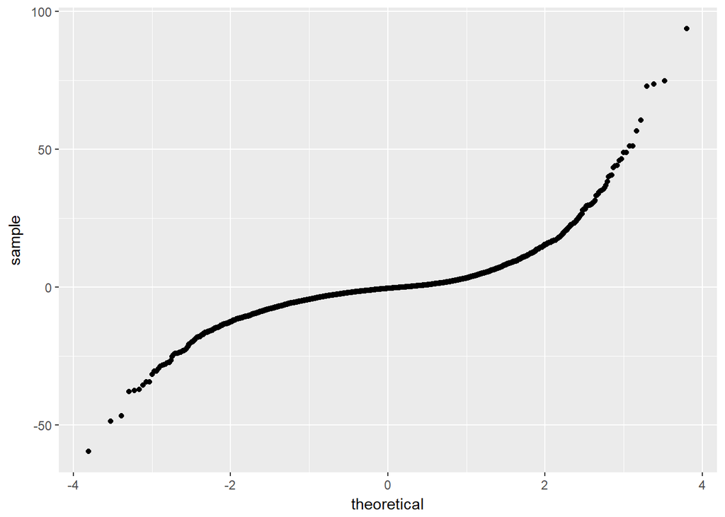

```r
ggplot(t, aes(sample=port3_absreturn)) +  stat_qq()
```

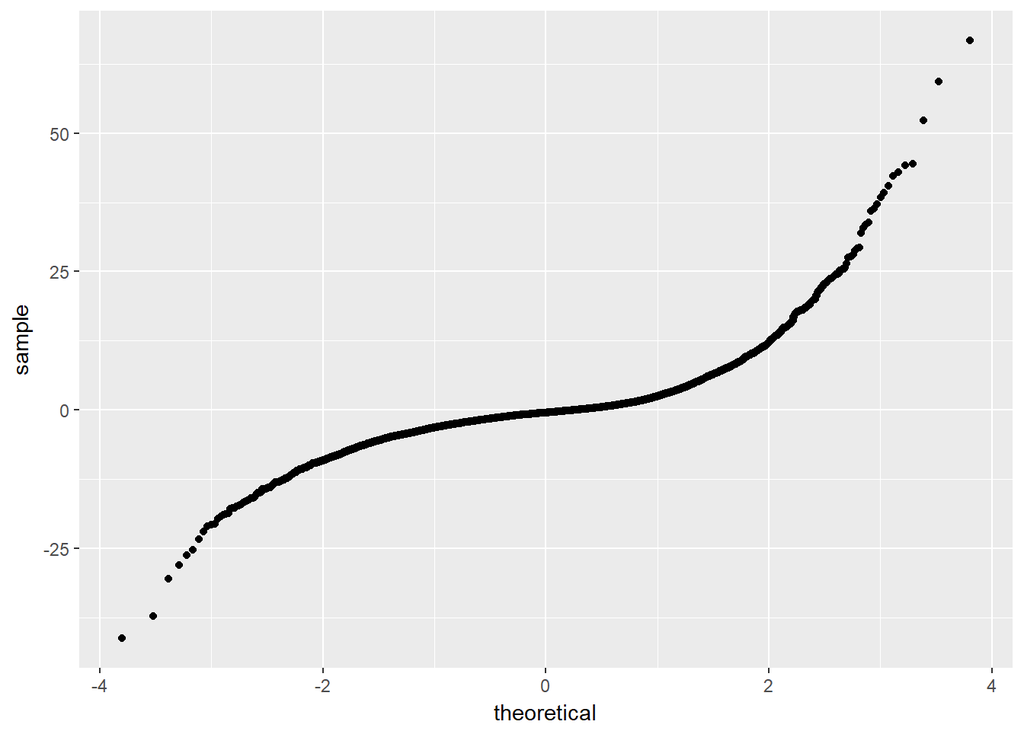

```r
ggplot(t, aes(sample=port4_absreturn)) +  stat_qq()
```

```r
#a = 4500
#c = 7068

#print("Absolute Return in 10 years")

#ggplot(t[a:c,], aes(sample=port1_absreturn)) +  stat_qq()
#ggplot(t[a:c,], aes(sample=port2_absreturn)) +  stat_qq()
#ggplot(t[a:c,], aes(sample=port3_absreturn)) +  stat_qq()
#ggplot(t[a:c,], aes(sample=port4_absreturn)) +  stat_qq()
```

# QQ plot of Percentage Return

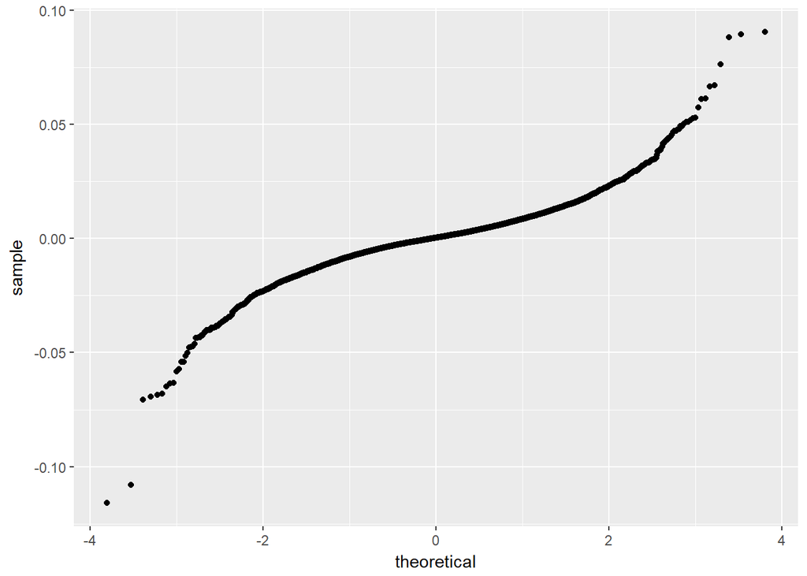

```r
ggplot(t, aes(sample=port1_Perreturn)) +  stat_qq()
```

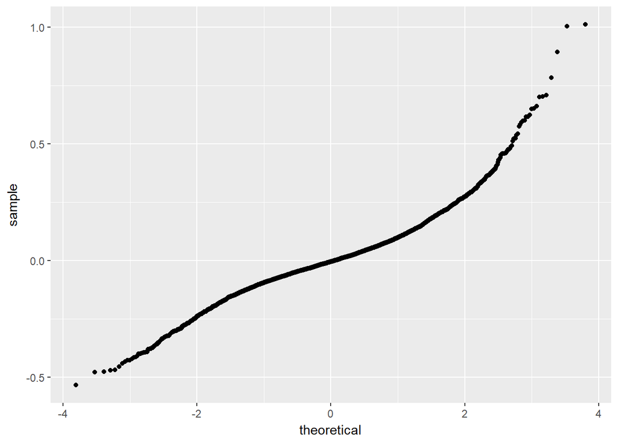

```r
ggplot(t, aes(sample=port2_Perreturn)) +  stat_qq()
```

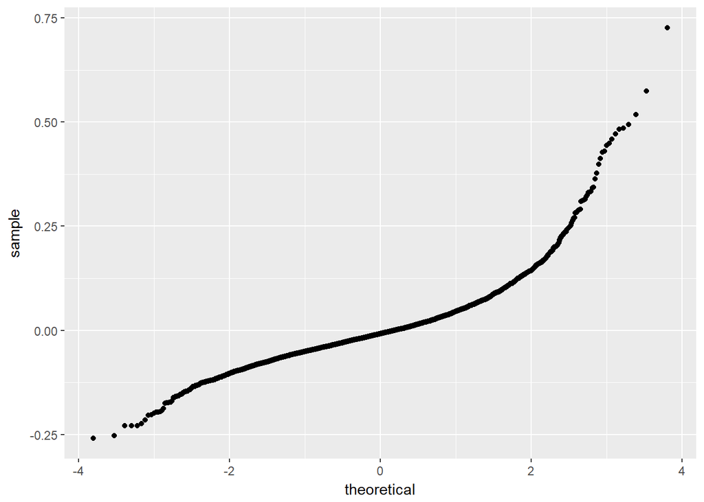

```r
ggplot(t, aes(sample=port3_Perreturn)) +  stat_qq()
```

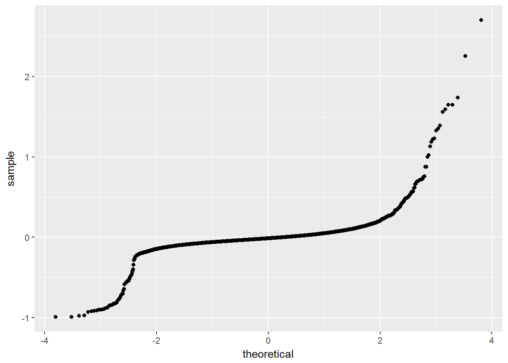

```r
ggplot(t, aes(sample=port4_Perreturn)) +  stat_qq()
```

```r
#a = 4500
#c = 7068

#print("Percentage Return in 10 years")

#ggplot(t[a:c,], aes(sample=port1_Perreturn)) +  stat_qq()
#ggplot(t[a:c,], aes(sample=port2_Perreturn)) +  stat_qq()
#ggplot(t[a:c,], aes(sample=port3_Perreturn)) +  stat_qq()
#ggplot(t[a:c,], aes(sample=port4_Perreturn)) +  stat_qq()
```

# Statistics of Absolute Return

```r
cat(red("absreturn Statistics in all time\n"))
```

```
## absreturn Statistics in all time
```

```r
cat(blue("Portfolio 1\n"))
```

```
## Portfolio 1
```

```r
stat.desc(t$port1_absreturn)
```

```
##      nbr.val     nbr.null       nbr.na          min          max
## 7068.0000000    5.0000000    0.0000000 -104.1300050  106.8499760
##        range          sum       median         mean      SE.mean
##  210.9799810 1824.8309430    0.2449955    0.2581821    0.1523736
## CI.mean.0.95          var      std.dev     coef.var
##    0.2986980  164.1028735   12.8102644   49.6171708
```

```r
describe(t$port1_absreturn)
```

```
##    vars    n mean    sd median trimmed  mad     min    max  range  skew
## X1    1 7068 0.26 12.81   0.24    0.37 7.42 -104.13 106.85 210.98 -0.09
##    kurtosis   se
## X1     6.04 0.15
```

```r
cat(blue("Portfolio 2\n"))
```

```
## Portfolio 2
```

```r
stat.desc(t$port2_absreturn)
```

```
##       nbr.val      nbr.null        nbr.na           min           max
## 7068.00000000    0.00000000    0.00000000  -66.18886678   85.63080163
##         range           sum        median          mean       SE.mean
##  151.81966841  124.09293128   -0.16508487    0.01755701    0.08279852
##  CI.mean.0.95           var       std.dev      coef.var
##    0.16230992   48.45534806    6.96098758  396.47915231
```

```r
describe(t$port2_absreturn)
```

```
##    vars    n mean   sd median trimmed  mad    min   max  range skew
## X1    1 7068 0.02 6.96  -0.17    -0.1 3.16 -66.19 85.63 151.82 1.12
##    kurtosis   se
## X1    20.89 0.08
```

```r
cat(blue("Portfolio 3\n"))
```

```
## Portfolio 3
```

```r
stat.desc(t$port3_absreturn)
```

```
##       nbr.val      nbr.null        nbr.na           min           max
##  7.068000e+03  0.000000e+00  0.000000e+00 -5.950167e+01  9.359266e+01
##         range           sum        median          mean       SE.mean
##  1.530943e+02 -1.568673e+03 -4.497835e-01 -2.219402e-01  8.008889e-02
##  CI.mean.0.95           var       std.dev      coef.var
##  1.569982e-01  4.533578e+01  6.733185e+00 -3.033784e+01
```

```r
describe(t$port3_absreturn)
```

```
##    vars    n  mean   sd median trimmed  mad   min   max  range skew
## X1    1 7068 -0.22 6.73  -0.45   -0.52 3.14 -59.5 93.59 153.09 1.84
##    kurtosis   se
## X1    21.69 0.08
```

```r
cat(blue("Portfolio 4\n"))
```

```
## Portfolio 4
```

```r
stat.desc(t$port4_absreturn)
```

```
##      nbr.val     nbr.null       nbr.na          min          max
## 7068.0000000    0.0000000    0.0000000  -41.2258381   66.6885128
##        range          sum       median         mean      SE.mean
##  107.9143509 -753.1361740   -0.4881543   -0.1065558    0.0606668
## CI.mean.0.95          var      std.dev     coef.var
##    0.1189251   26.0134990    5.1003430  -47.8654801
```

```r
describe(t$port4_absreturn)
```

```
##    vars    n  mean  sd median trimmed mad    min   max  range skew
## X1    1 7068 -0.11 5.1  -0.49   -0.45 2.3 -41.23 66.69 107.91 2.17
##    kurtosis   se
## X1    19.89 0.06
```

```r
a = 4500
c = 7068

cat(red("absreturn Statistics in 10 years\n"))
```

```
## absreturn Statistics in 10 years
```

```r
cat(blue("Portfolio 1\n"))
```

```
## Portfolio 1
```

```r
stat.desc(t$port1_absreturn[a:c])
```

```
##      nbr.val     nbr.null       nbr.na          min          max
## 2569.0000000    2.0000000    0.0000000 -104.1300050  106.8499760
##        range          sum       median         mean      SE.mean
##  210.9799810 1245.0708030    0.6899410    0.4846519    0.3214684
## CI.mean.0.95          var      std.dev     coef.var
##    0.6303636  265.4854534   16.2937244   33.6194358
```

```r
describe(t$port1_absreturn[a:c])
```

```
##    vars    n mean    sd median trimmed   mad     min    max  range  skew
## X1    1 2569 0.48 16.29   0.69    0.69 11.49 -104.13 106.85 210.98 -0.03
##    kurtosis   se
## X1     4.03 0.32
```

```r
cat(blue("Portfolio 2\n"))
```

```
## Portfolio 2
```

```r
stat.desc(t$port2_absreturn[a:c])
```

```
##       nbr.val      nbr.null        nbr.na           min           max
## 2569.00000000    0.00000000    0.00000000  -66.18886678   85.63080163
##         range           sum        median          mean       SE.mean
##  151.81966841  232.13102047   -0.20909930    0.09035851    0.18311914
##  CI.mean.0.95           var       std.dev      coef.var
##    0.35907617   86.14530248    9.28144937  102.71803998
```

```r
describe(t$port2_absreturn[a:c])
```

```
##    vars    n mean   sd median trimmed  mad    min   max  range skew
## X1    1 2569 0.09 9.28  -0.21   -0.08 4.45 -66.19 85.63 151.82 1.16
##    kurtosis   se
## X1    15.69 0.18
```

```r
cat(blue("Portfolio 3\n"))
```

```
## Portfolio 3
```

```r
stat.desc(t$port3_absreturn[a:c])
```

```
##      nbr.val     nbr.null       nbr.na          min          max
## 2569.0000000    0.0000000    0.0000000  -59.5016726   93.5926578
##        range          sum       median         mean      SE.mean
##  153.0943304 -778.0434761   -1.2038082   -0.3028585    0.1875655
## CI.mean.0.95          var      std.dev     coef.var
##    0.3677951   90.3795653    9.5068168  -31.3902925
```

```r
describe(t$port3_absreturn[a:c])
```

```
##    vars    n mean   sd median trimmed  mad   min   max  range skew
## X1    1 2569 -0.3 9.51   -1.2   -0.85 5.35 -59.5 93.59 153.09 1.61
##    kurtosis   se
## X1       13 0.19
```

```r
cat(blue("Portfolio 4\n"))
```

```
## Portfolio 4
```

```r
stat.desc(t$port4_absreturn[a:c])
```

```
##      nbr.val     nbr.null       nbr.na          min          max
## 2569.0000000    0.0000000    0.0000000  -41.2258381   66.6885128
##        range          sum       median         mean      SE.mean
##  107.9143509 -366.3117368   -1.0393078   -0.1425892    0.1379877
## CI.mean.0.95          var      std.dev     coef.var
##    0.2705784   48.9152825    6.9939461  -49.0496094
```

```r
describe(t$port4_absreturn[a:c])
```

```
##    vars    n  mean   sd median trimmed  mad    min   max  range skew
## X1    1 2569 -0.14 6.99  -1.04   -0.72 3.69 -41.23 66.69 107.91 1.88
##    kurtosis   se
## X1    12.36 0.14
```

# Statistics of Percentage Return

```r
cat(red("Percentage Statistics in all time\n"))
```

```
## Percentage Statistics in all time
```

```r
cat(blue("Portfolio 1\n"))
```

```
## Portfolio 1
```

```r
stat.desc(t$port1_Perreturn)
```

```
##       nbr.val      nbr.null        nbr.na           min           max
##  7.068000e+03  5.000000e+00  0.000000e+00 -1.158004e-01  9.034978e-02
##         range           sum        median          mean       SE.mean
##  2.061501e-01  1.396168e+00  2.987510e-04  1.975336e-04  1.317215e-04
##  CI.mean.0.95           var       std.dev      coef.var
##  2.582137e-04  1.226337e-04  1.107401e-02  5.606140e+01
```

```r
describe(t$port1_Perreturn)
```

```
##    vars    n mean   sd median trimmed  mad   min  max range  skew kurtosis
## X1    1 7068    0 0.01      0       0 0.01 -0.12 0.09  0.21 -0.21     9.11
##    se
## X1  0
```

```r
cat(blue("Portfolio 2\n"))
```

```
## Portfolio 2
```

```r
stat.desc(t$port2_Perreturn)
```

```
##       nbr.val      nbr.null        nbr.na           min           max
##  7.068000e+03  0.000000e+00  0.000000e+00 -5.341734e-01  1.010722e+00
##         range           sum        median          mean       SE.mean
##  1.544895e+00  9.578831e+00 -5.579578e-03  1.355239e-03  1.440548e-03
##  CI.mean.0.95           var       std.dev      coef.var
##  2.823907e-03  1.466737e-02  1.211089e-01  8.936350e+01
```

```r
describe(t$port2_Perreturn)
```

```
##    vars    n mean   sd median trimmed  mad   min  max range skew kurtosis
## X1    1 7068    0 0.12  -0.01       0 0.09 -0.53 1.01  1.54 0.74      4.7
##    se
## X1  0
```

```r
cat(blue("Portfolio 3\n"))
```

```
## Portfolio 3
```

```r
stat.desc(t$port3_Perreturn)
```

```
##       nbr.val      nbr.null        nbr.na           min           max
##  7.068000e+03  0.000000e+00  0.000000e+00 -2.589839e-01  7.257278e-01
##         range           sum        median          mean       SE.mean
##  9.847117e-01 -1.043397e+01 -7.951688e-03 -1.476227e-03  7.413782e-04
##  CI.mean.0.95           var       std.dev      coef.var
##  1.453323e-03  3.884867e-03  6.232870e-02 -4.222162e+01
```

```r
describe(t$port3_Perreturn)
```

```
##    vars    n mean   sd median trimmed  mad   min  max range skew kurtosis
## X1    1 7068    0 0.06  -0.01   -0.01 0.04 -0.26 0.73  0.98 1.85    11.18
##    se
## X1  0
```

```r
cat(blue("Portfolio 4\n"))
```

```
## Portfolio 4
```

```r
stat.desc(t$port4_Perreturn)
```

```
##       nbr.val      nbr.null        nbr.na           min           max
##  7.068000e+03  0.000000e+00  0.000000e+00 -9.915351e-01  2.701490e+00
##         range           sum        median          mean       SE.mean
##  3.693025e+00 -2.807680e+01 -1.331977e-02 -3.972382e-03  1.540487e-03
##  CI.mean.0.95           var       std.dev      coef.var
##  3.019817e-03  1.677308e-02  1.295109e-01 -3.260284e+01
```

```r
describe(t$port4_Perreturn)
```

```
##    vars    n mean   sd median trimmed  mad   min max range skew kurtosis
## X1    1 7068    0 0.13  -0.01   -0.01 0.05 -0.99 2.7  3.69 3.83    79.68
##    se
## X1  0
```

```r
a = 4500
c = 7068

cat(red("Percentage Statistics in 10 years\n"))
```

```
## Percentage Statistics in 10 years
```

```r
cat(blue("Portfolio 1\n"))
```

```
## Portfolio 1
```

```r
stat.desc(t$port1_Perreturn[a:c])
```

```
##       nbr.val      nbr.null        nbr.na           min           max
##  2.569000e+03  2.000000e+00  0.000000e+00 -1.158004e-01  9.034978e-02
##         range           sum        median          mean       SE.mean
##  2.061501e-01  6.963870e-01  3.970065e-04  2.710732e-04  2.535308e-04
##  CI.mean.0.95           var       std.dev      coef.var
##  4.971456e-04  1.651299e-04  1.285029e-02  4.740523e+01
```

```r
describe(t$port1_Perreturn[a:c])
```

```
##    vars    n mean   sd median trimmed  mad   min  max range  skew kurtosis
## X1    1 2569    0 0.01      0       0 0.01 -0.12 0.09  0.21 -0.14    11.16
##    se
## X1  0
```

```r
cat(blue("Portfolio 2\n"))
```

```
## Portfolio 2
```

```r
stat.desc(t$port2_Perreturn[a:c])
```

```
##       nbr.val      nbr.null        nbr.na           min           max
##  2.569000e+03  0.000000e+00  0.000000e+00 -5.341734e-01  1.010722e+00
##         range           sum        median          mean       SE.mean
##  1.544895e+00  8.468309e+00 -3.916200e-03  3.296344e-03  2.518123e-03
##  CI.mean.0.95           var       std.dev      coef.var
##  4.937758e-03  1.628988e-02  1.276318e-01  3.871920e+01
```

```r
describe(t$port2_Perreturn[a:c])
```

```
##    vars    n mean   sd median trimmed  mad   min  max range skew kurtosis
## X1    1 2569    0 0.13      0       0 0.08 -0.53 1.01  1.54 1.14     7.74
##    se
## X1  0
```

```r
cat(blue("Portfolio 3\n"))
```

```
## Portfolio 3
```

```r
stat.desc(t$port3_Perreturn[a:c])
```

```
##       nbr.val      nbr.null        nbr.na           min           max
##  2.569000e+03  0.000000e+00  0.000000e+00 -2.589839e-01  5.177411e-01
##         range           sum        median          mean       SE.mean
##  7.767250e-01 -2.571134e+00 -1.121156e-02 -1.000831e-03  1.422284e-03
##  CI.mean.0.95           var       std.dev      coef.var
##  2.788939e-03  5.196806e-03  7.208888e-02 -7.202905e+01
```

```r
describe(t$port3_Perreturn[a:c])
```

```
##    vars    n mean   sd median trimmed  mad   min  max range skew kurtosis
## X1    1 2569    0 0.07  -0.01   -0.01 0.05 -0.26 0.52  0.78 1.72      7.7
##    se
## X1  0
```

```r
cat(blue("Portfolio 4\n"))
```

```
## Portfolio 4
```

```r
stat.desc(t$port4_Perreturn[a:c])
```

```
##       nbr.val      nbr.null        nbr.na           min           max
##  2.569000e+03  0.000000e+00  0.000000e+00 -9.901604e-01  1.328718e+00
##         range           sum        median          mean       SE.mean
##  2.318879e+00 -1.535557e+01 -1.620530e-02 -5.977255e-03  2.366148e-03
##  CI.mean.0.95           var       std.dev      coef.var
##  4.639751e-03  1.438295e-02  1.199289e-01 -2.006421e+01
```

```r
describe(t$port4_Perreturn[a:c])
```

```
##    vars    n  mean   sd median trimmed  mad   min  max range  skew
## X1    1 2569 -0.01 0.12  -0.02   -0.01 0.05 -0.99 1.33  2.32 -0.01
##    kurtosis se
## X1     28.2  0
```

# Statistics Comparison

```r
base <- t[,c(9,11,13,15,10,12,14,16)]
colnames(base) <- c("port1_absreturn","port2_absreturn","port3_absreturn","port4_absreturn","port1_Perreturn","port2_Perreturn","port3_Perreturn","port4_Perreturn")

#base <- t[,c(9,11,13,15)]
#colnames(base) <- c("port1_absreturn","port2_absreturn","port3_absreturn","port4_absreturn")

stat <- sapply(base,sum) %>%
  rbind(sapply(base,mean)) %>%
  rbind(sapply(base,mean)*252) %>%
  rbind(sapply(base,var)) %>%
  rbind(sapply(base,skew)) %>%
  rbind(sapply(base,kurtosis))

rownames(stat) <- c("sum","mean","annual mean","var","skew","kurtosis")

print("Statistics in all time")
```

```
## [1] "Statistics in all time"
```

```r
print(stat)
```

```
##             port1_absreturn port2_absreturn port3_absreturn
## sum           1824.83094300    124.09293128   -1568.6732339
## mean             0.25818208      0.01755701      -0.2219402
## annual mean     65.06188422      4.42436597     -55.9289268
## var            164.10287352     48.45534806      45.3357845
## skew            -0.09345666      1.11893401       1.8438698
## kurtosis         6.04077205     20.89515508      21.6945097
##             port4_absreturn port1_Perreturn port2_Perreturn
## sum            -753.1361740    1.3961676831     9.578830988
## mean             -0.1065558    0.0001975336     0.001355239
## annual mean     -26.8520537    0.0497784743     0.341520290
## var              26.0134990    0.0001226337     0.014667371
## skew              2.1692287   -0.2058097977     0.742844321
## kurtosis         19.8926122    9.1102205378     4.699127008
##             port3_Perreturn port4_Perreturn
## sum           -10.433972404   -28.076795949
## mean           -0.001476227    -0.003972382
## annual mean    -0.372009203    -1.001040263
## var             0.003884867     0.016773080
## skew            1.852473990     3.832588266
## kurtosis       11.188373938    79.704847934
```

```r
a = 4500
c = 7068

stat2 <- sapply(base[a:c,],sum) %>%
  rbind(sapply(base[a:c,],mean)) %>%
  rbind(sapply(base[a:c,],mean)*252) %>%
  rbind(sapply(base[a:c,],var)) %>%
  rbind(sapply(base[a:c,],skew)) %>%
  rbind(sapply(base[a:c,],kurtosis))

rownames(stat2) <- c("sum","mean","annual mean","var","skew","kurtosis")

print("Statistics in 10 years")
```

```
## [1] "Statistics in 10 years"
```

```r
print(stat2)
```

```
##             port1_absreturn port2_absreturn port3_absreturn
## sum           1245.07080300    232.13102047    -778.0434761
## mean             0.48465193      0.09035851      -0.3028585
## annual mean    122.13228585     22.77034533     -76.3203410
## var            265.48545338     86.14530248      90.3795653
## skew            -0.02778075      1.15829414       1.6149895
## kurtosis         4.03048207     15.70434071      13.0163718
##             port4_absreturn port1_Perreturn port2_Perreturn
## sum            -366.3117368    0.6963870344     8.468308827
## mean             -0.1425892    0.0002710732     0.003296344
## annual mean     -35.9324864    0.0683104448     0.830678795
## var              48.9152825    0.0001651299     0.016289884
## skew              1.8785511   -0.1364247557     1.135255986
## kurtosis         12.3703123   11.1710343895     7.749422412
##             port3_Perreturn port4_Perreturn
## sum            -2.571133954   -15.355567485
## mean           -0.001000831    -0.005977255
## annual mean    -0.252209325    -1.506268200
## var             0.005196806     0.014382946
## skew            1.720441423    -0.008924747
## kurtosis        7.704433697    28.221119624
```

# Culmulative Return

See how the cost of options and straddles ruined your return

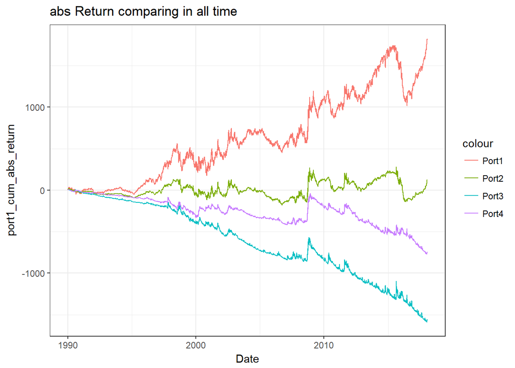

```r
t$port1_cum_abs_return<-cumsum(t$port1_absreturn)
t$port2_cum_abs_return<-cumsum(t$port2_absreturn)
t$port3_cum_abs_return<-cumsum(t$port3_absreturn)
t$port4_cum_abs_return<-cumsum(t$port4_absreturn)

ggplot(t,aes(x=Date)) +
  geom_line(aes(y=port1_cum_abs_return,color="Port1")) +
  geom_line(aes(y=port2_cum_abs_return,color="Port2")) +
  geom_line(aes(y=port3_cum_abs_return,color="Port3")) +
  geom_line(aes(y=port4_cum_abs_return,color="Port4")) +
  theme_bw() +
  ggtitle("abs Return comparing in all time")
```

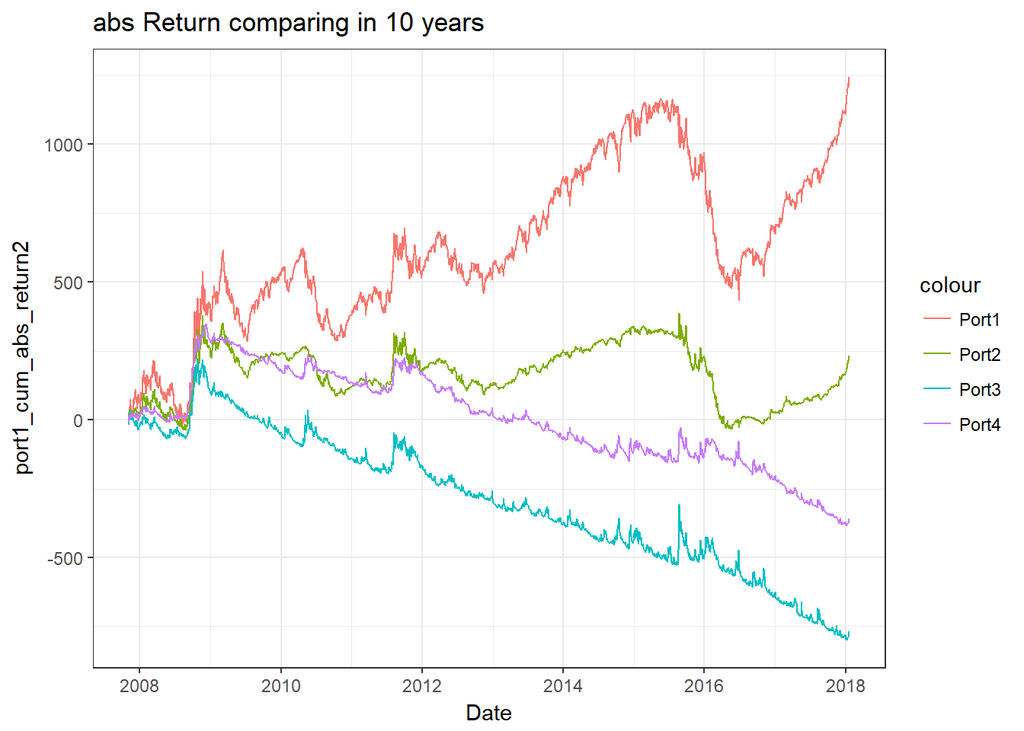

```r
a = 4500
c = 7068
t$port1_cum_abs_return2[a:c]<-cumsum(t$port1_absreturn[a:c])
t$port2_cum_abs_return2[a:c]<-cumsum(t$port2_absreturn[a:c])
t$port3_cum_abs_return2[a:c]<-cumsum(t$port3_absreturn[a:c])
t$port4_cum_abs_return2[a:c]<-cumsum(t$port4_absreturn[a:c])

ggplot(t[a:c,],aes(x=Date)) +
  geom_line(aes(y=port1_cum_abs_return2,color="Port1")) +
  geom_line(aes(y=port2_cum_abs_return2,color="Port2")) +
  geom_line(aes(y=port3_cum_abs_return2,color="Port3")) +
  geom_line(aes(y=port4_cum_abs_return2,color="Port4")) +
  theme_bw() +
  ggtitle("abs Return comparing in 10 years")
```